# Analysis_2016_Presidential_Campaign_Contribution _NY_Data Exploration.rmd

### Distribution of Contribution Receipt Amount by Contribution Year, Month, Date

*Boxplot for contribution of contribution amounts received by Year, Month, Day.*

```
##  contb_receipt_year contb_receipt_month contb_receipt_day
##  2013:    2         10     : 8358       29     : 2421
##  2014:   31         9      : 6590       30     : 2420
##  2015:10742         7      : 5774       28     : 2249
##  2016:45923         8      : 5199       26     : 2119
##                     4      : 4943       01     : 1966
##                     6      : 4803       09     : 1948
##                     (Other):21031       (Other):43575
##  contb_receipt_amt        n              cum_amt
##  Min.   :  -10100   Min.   :   1.00   Min.   : -210600
##  1st Qu.:      20   1st Qu.:   1.00   1st Qu.:      37
##  Median :      56   Median :   1.00   Median :      96
##  Mean   :    1633   Mean   :  11.45   Mean   :    3027
##  3rd Qu.:     145   3rd Qu.:   3.00   3rd Qu.:     350
##  Max.   :12777706   Max.   :1535.00   Max.   :12777706
##
```

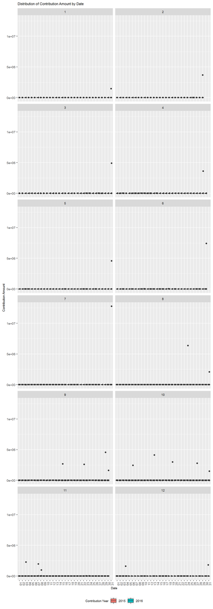

*Using ylim from 0:3000*

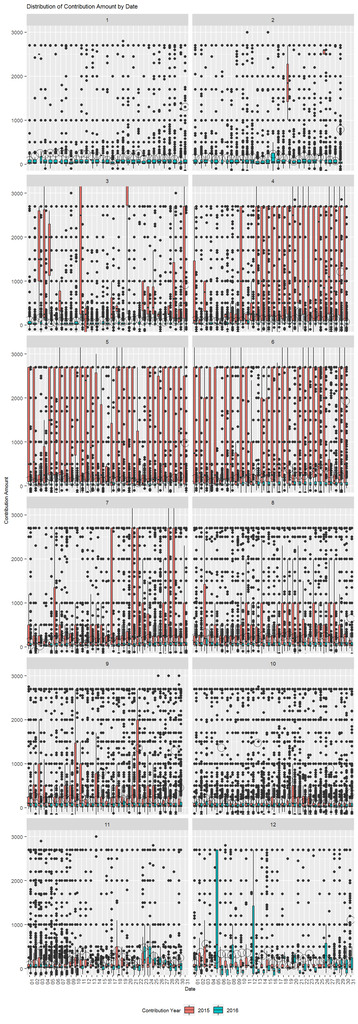

*Using ylim from 0:100*

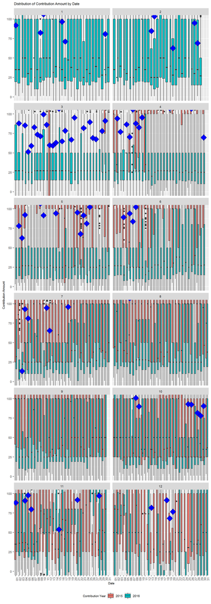

## *Bivariate Analysis*

**1.Talk about some of the relationships you observed in this part of the investigation. How did the feature(s) of interest vary with other features in the dataset?**

> The sum of contribution receipt amount `contb_receipt_amt` indicated strong correlation with party affiliation `cand_party`. Given New York is a blue state, it is not surprising that the Democratic received distinctively higher contribution amount $154 millions,compared to other parties. The Republican party came second with $17.5 millions

> The sum of contribution receipt amount `contb_receipt_amt` also strongly correlates with candidate `cand_nm`. Clinton, Hillary Rodham received the most contribution . Sanders, Bernard in second place, Trump, Donald J. came in third.

> The spikes and small jumps also coincides with presidential campaign phases. Notably on June 30th, 2016, before Republican National Convention and Democratic National Convention, there is a spike in contribution. Another obvious spike was starting September 26th till September 30th, 2016, after the first Presidential Debate.

> There were small jumps in contribution after the 3rd presidential debate on October 19, 2016, and the week before Election Day on November 8th, 2016.

**2. Did you observe any interesting relationships between the other features (not the main feature(s) of interest)?**

> Comparing the distributions for contribution amount across top 20 cities, there were only some small variations, not any significant trends, except for New york.

**3. What was the strongest relationship you found?**

> The sum of contribution amounts has the strongest correlations with candidate party affiliation `cand_party`, contb_receipt_dt, and candidate himself/herself `cand_nm`. The sum of contribution amounts also had a seosonal trend, and changed along with the various campaign phases.

## *Multivariate Plots*

*Sum of Contribution Receipt Amount for Top 5 Candidates (by contribution receipt amount) by Date*

```
## # A tibble: 2,109 x 12
##    cand_nm contb_receipt_y~ contb_receipt_m~ contb_receipt_d~     n sum_amt
##    <fct>   <fct>            <fct>            <fct>            <int>   <dbl>
##  1 Clinto~ 2016             7                31                2514  1.31e7
##  2 Clinto~ 2016             6                30                1891  7.68e6
##  3 Clinto~ 2016             8                24                 857  6.49e6
##  4 Clinto~ 2016             3                31                1313  5.07e6
##  5 Clinto~ 2016             9                29                3249  4.92e6
##  6 Clinto~ 2016             5                31                1582  4.75e6
##  7 Clinto~ 2016             10               13                2033  4.39e6
##  8 Clinto~ 2016             2                29                 881  3.83e6
##  9 Clinto~ 2016             4                29                1638  3.75e6
## 10 Clinto~ 2016             10               19                5015  3.43e6
## # ... with 2,099 more rows, and 6 more variables: mean <dbl>, max <dbl>,
## #   min <dbl>, median <dbl>, count_proportion <dbl>, sum_proportion <dbl>
```

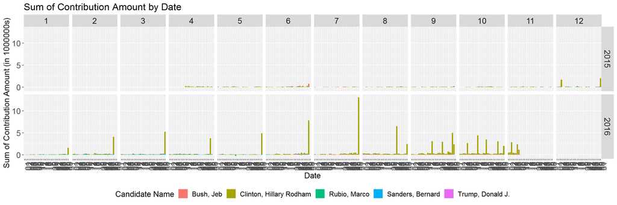

*Sum of Monthly Contribution Receipt Amount for Candidate Party Affiliation (Year 2015 and 2016)*

```
## # A tibble: 89 x 11
##    cand_party contb_receipt_y~ contb_receipt_m~     n sum_amt  mean    max
##    <fct>      <fct>            <fct>            <int>   <dbl> <dbl>  <dbl>
##  1 Democratic 2016             10               85291  2.20e7  258. 4.13e6
##  2 Democratic 2016             9                64206  2.03e7  316. 4.56e6
##  3 Democratic 2016             7                43966  1.77e7  404. 1.28e7
##  4 Democratic 2016             8                41603  1.48e7  355. 6.36e6
##  5 Democratic 2016             6                36390  1.21e7  334. 7.40e6
##  6 Democratic 2016             3                57869  9.21e6  159. 4.90e6
##  7 Democratic 2016             2                38527  8.64e6  224. 3.69e6
##  8 Democratic 2016             11               42570  8.56e6  201. 2.27e6
##  9 Democratic 2016             4                59720  8.25e6  138. 3.60e6
## 10 Democratic 2016             5                44744  7.61e6  170. 4.58e6
## # ... with 79 more rows, and 4 more variables: min <dbl>, median <dbl>,
## #   count_proportion <dbl>, sum_proportion <dbl>
```

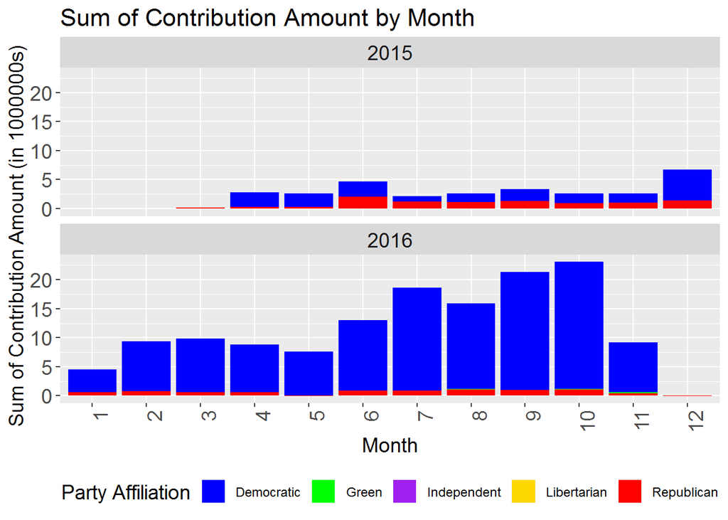

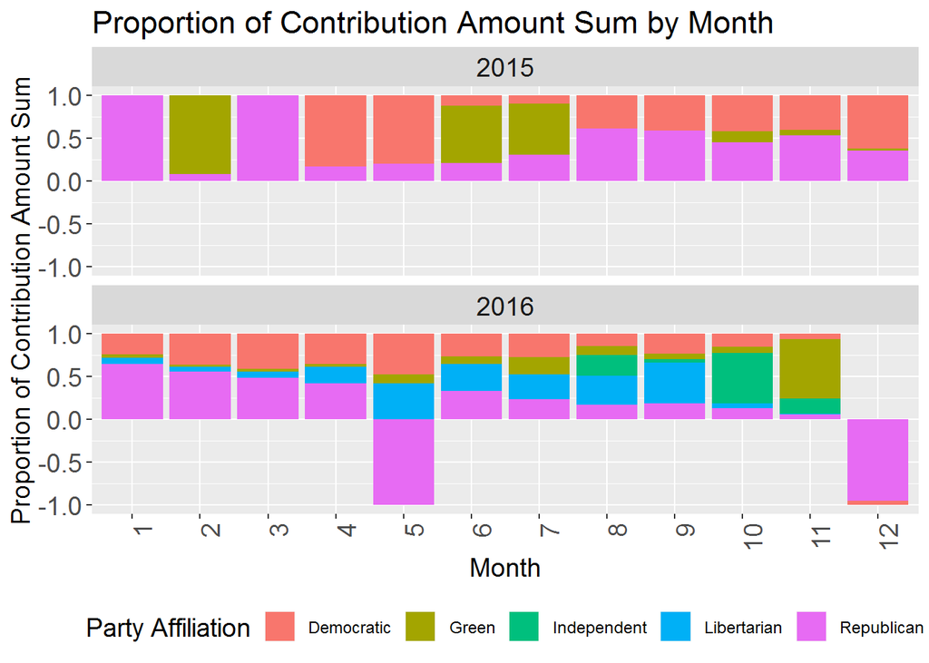

*Sum of Monthly Contribution Receipt Amount for Top 5 Candidates (Year 2015 and 2016)*

```
## # A tibble: 89 x 11
##    cand_nm contb_receipt_y~ contb_receipt_m~     n sum_amt  mean    max
##    <fct>   <fct>            <fct>            <int>   <dbl> <dbl>  <dbl>
##  1 Clinto~ 2016             10               85291  2.20e7  258. 4.13e6
##  2 Clinto~ 2016             9                64202  2.03e7  316. 4.56e6
##  3 Clinto~ 2016             7                41484  1.78e7  428. 1.28e7
##  4 Clinto~ 2016             8                41568  1.48e7  355. 6.36e6
##  5 Clinto~ 2016             6                25655  1.19e7  463. 7.40e6
##  6 Clinto~ 2016             11               42570  8.56e6  201. 2.27e6
##  7 Clinto~ 2016             3                16276  7.41e6  455. 4.90e6
##  8 Clinto~ 2016             2                14454  7.19e6  498. 3.69e6
##  9 Clinto~ 2016             5                18934  6.78e6  358. 4.58e6
## 10 Clinto~ 2016             4                19838  6.74e6  340. 3.60e6
## # ... with 79 more rows, and 4 more variables: min <dbl>, median <dbl>,
## #   count_proportion <dbl>, sum_proportion <dbl>
```

```
## # A tibble: 55 x 11
##    cand_party contb_receipt_y~ contb_receipt_m~     n sum_amt  mean    max
##    <fct>      <fct>            <fct>            <int>   <dbl> <dbl>  <dbl>
##  1 Democratic 2016             10               85291  2.20e7  258. 4.13e6
##  2 Democratic 2016             9                64206  2.03e7  316. 4.56e6
##  3 Democratic 2016             7                43966  1.77e7  404. 1.28e7
##  4 Democratic 2016             8                41603  1.48e7  355. 6.36e6
##  5 Democratic 2016             6                36390  1.21e7  334. 7.40e6
##  6 Democratic 2016             3                57869  9.21e6  159. 4.90e6
##  7 Democratic 2016             2                38527  8.64e6  224. 3.69e6
##  8 Democratic 2016             11               42570  8.56e6  201. 2.27e6
##  9 Democratic 2016             4                59720  8.25e6  138. 3.60e6
## 10 Democratic 2016             5                44744  7.61e6  170. 4.58e6
## # ... with 45 more rows, and 4 more variables: min <dbl>, median <dbl>,
## #   count_proportion <dbl>, sum_proportion <dbl>
```

```
## # A tibble: 89 x 12
##    cand_party cand_nm contb_receipt_y~ contb_receipt_m~     n sum_amt  mean
##    <fct>      <fct>   <fct>            <fct>            <int>   <dbl> <dbl>
##  1 Democratic Clinto~ 2016             10               85291  2.20e7  258.
##  2 Democratic Clinto~ 2016             9                64202  2.03e7  316.
##  3 Democratic Clinto~ 2016             7                41484  1.78e7  428.
##  4 Democratic Clinto~ 2016             8                41568  1.48e7  355.
##  5 Democratic Clinto~ 2016             6                25655  1.19e7  463.
##  6 Democratic Clinto~ 2016             11               42570  8.56e6  201.
##  7 Democratic Clinto~ 2016             3                16276  7.41e6  455.
##  8 Democratic Clinto~ 2016             2                14454  7.19e6  498.
##  9 Democratic Clinto~ 2016             5                18934  6.78e6  358.
## 10 Democratic Clinto~ 2016             4                19838  6.74e6  340.
## # ... with 79 more rows, and 5 more variables: max <dbl>, min <dbl>,
## #   median <dbl>, count_proportion <dbl>, sum_proportion <dbl>
```

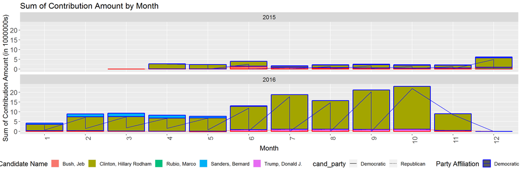

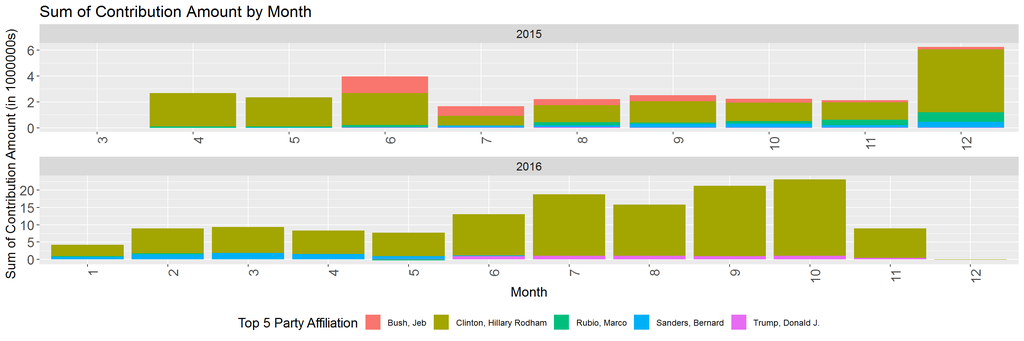

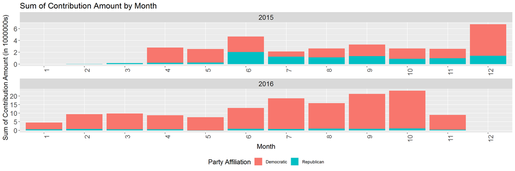

*Count of Monthly Contribution Receipt Amount for Top 5 Candidates (Year 2015 and 2016)*

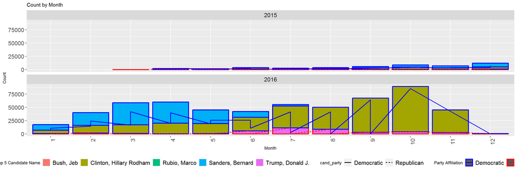

*Sum of Monthly Contribution Receipt Amount for Top 10 Contributor Cities (Year 2015 and 2016)*

```
## # A tibble: 226 x 11
##    contbr_city contb_receipt_y~ contb_receipt_m~     n sum_amt  mean    max
##    <fct>       <fct>            <fct>            <int>   <dbl> <dbl>  <dbl>
##  1 NEW YORK    2016             10               32569  1.83e7  560. 4.13e6
##  2 NEW YORK    2016             9                25666  1.66e7  647. 4.56e6
##  3 NEW YORK    2016             7                16988  1.56e7  915. 1.28e7
##  4 NEW YORK    2016             8                16454  1.24e7  752. 6.36e6
##  5 NEW YORK    2016             6                12611  1.03e7  821. 7.40e6
##  6 NEW YORK    2016             11               17223  7.08e6  411. 2.27e6
##  7 NEW YORK    2016             3                16787  7.05e6  420. 4.90e6
##  8 NEW YORK    2016             2                12818  6.32e6  493. 3.69e6
##  9 NEW YORK    2016             5                12972  5.92e6  457. 4.58e6
## 10 NEW YORK    2016             4                16786  5.77e6  344. 3.60e6
## # ... with 216 more rows, and 4 more variables: min <dbl>, median <dbl>,
## #   count_proportion <dbl>, sum_proportion <dbl>
```

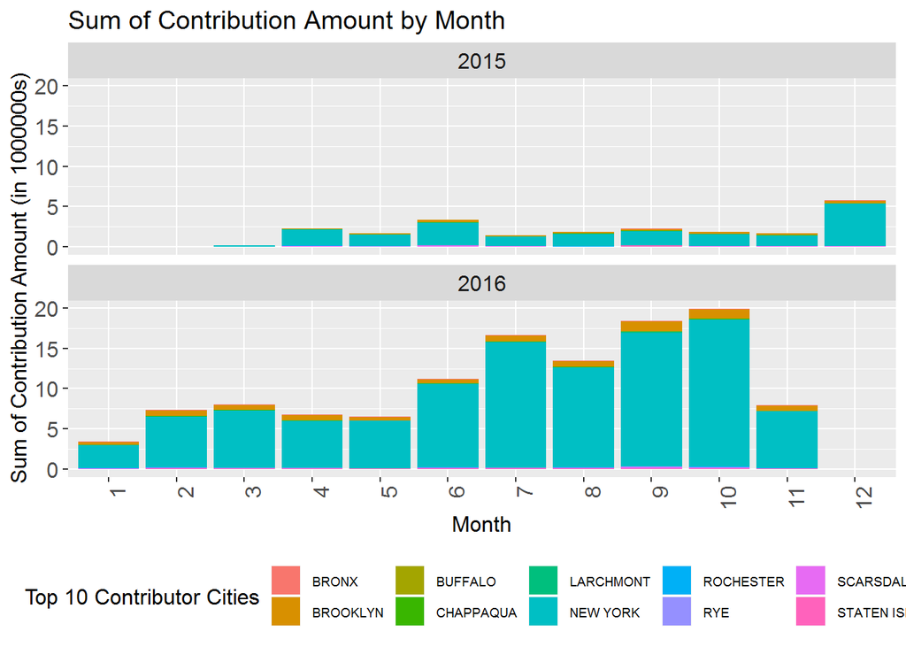

### Sum of Contribution Receipt Amount by Top 20 City for Top 5 Candidates

```
## # A tibble: 100 x 10
##    contbr_city cand_nm      n sum_amt  mean    max    min median
##    <fct>       <fct>    <int>   <dbl> <dbl>  <dbl>  <dbl>  <dbl>
##  1 NEW YORK    Clinto~ 155827  1.17e8 750.  1.28e7 -5400      50
##  2 BROOKLYN    Clinto~  56711  6.92e6 122.  3.70e3 -2700      25
##  3 NEW YORK    Sander~  40318  2.31e6  57.3 5.40e3 -6579      27
##  4 BROOKLYN    Sander~  26807  1.28e6  47.8 3.00e3 -3892.     27
##  5 BRONX       Clinto~   9016  7.07e5  78.4 2.70e3 -1790      25
##  6 ROCHESTER   Clinto~   5054  3.39e5  67.0 2.70e3 -1000      25
##  7 BRONX       Sander~   4199  1.58e5  37.7 2.50e3 -1870      25
##  8 STATEN ISL~ Clinto~   3636  3.64e5 100.  2.70e3  -250      25
##  9 ROCHESTER   Sander~   3629  1.41e5  38.8 2.70e3 -1413.     25
## 10 NEW YORK    Trump,~   3539  1.27e6 359.  5.40e3 -9300     100
## # ... with 90 more rows, and 2 more variables: count_proportion <dbl>,
## #   sum_proportion <dbl>
```

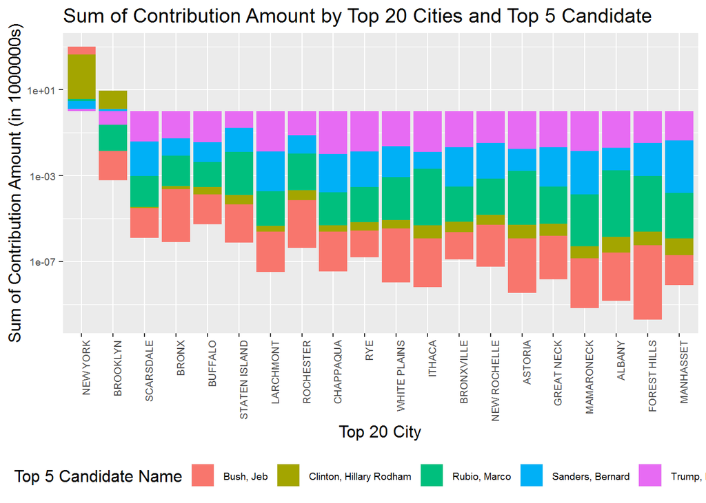

## *Multivariate Analyis*

**1. Talk about some of the relationships you observed in this part of the investigation. Were there features that strengthened each other in terms of looking at your feature(s) of interest?**

**2. Were there any interesting or surprising interactions between features?**

> The monthly sum of contribution amount for each candidate also contribute to the monthly sum of contribution amount for the party affiliation those candidates represent respectively.

**3. OPTIONAL: Did you create any models with your dataset? Discuss the strengths and limitations of your model.**  
>No, I didn’t create models with the dataset because most data are of factor/categorical data. also to make modele for prediction we need data for number of votes in states or Contributor’s Employer and Contributor’s Occupation where most of data NONE OR N/A and data like that

## *Final Plots and Summary*

*Plot One*

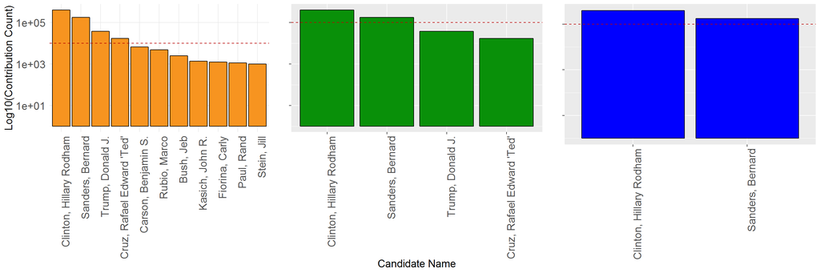

*Plot Two* ___

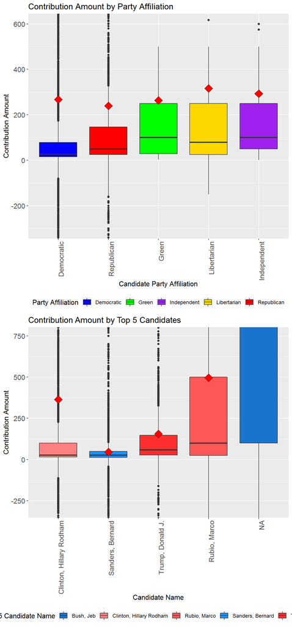

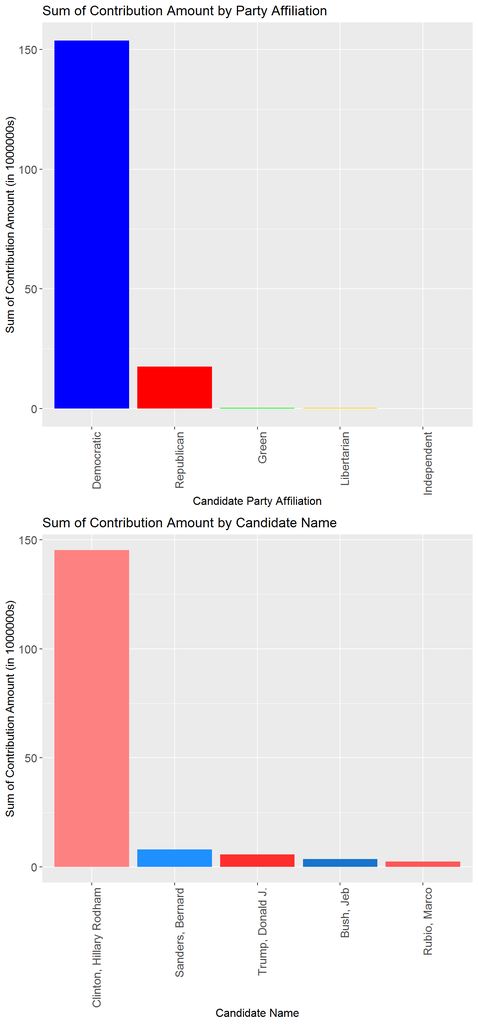

```
## # A tibble: 25 x 9
##    cand_nm      n sum_amt   mean    max    min median count_proportion
##    <fct>    <int>   <dbl>  <dbl>  <dbl>  <dbl>  <dbl>            <dbl>
##  1 Clinto~ 399522  1.45e8  364.  1.28e7  -5400   27           0.615
##  2 Sander~ 174564  8.05e6   46.1 5.40e3  -6579   27           0.269
##  3 Trump,~  36931  5.72e6  155.  1.00e4  -9300   59.2         0.0569
##  4 Bush, ~   2436  3.59e6 1473.  5.40e3  -5400 2400           0.00375
##  5 Rubio,~   4813  2.39e6  496.  1.08e4  -5400  100           0.00741
##  6 Cruz, ~  16785  1.65e6   98.1 1.08e4 -10100   35           0.0258
##  7 Kasich~   1350  8.65e5  641.  5.00e3  -2700  250           0.00208
##  8 Christ~    486  8.61e5 1772.  6.00e3  -5400 2700           0.000748
##  9 Carson~   6638  6.35e5   95.7 5.40e3  -3300   50           0.0102
## 10 Graham~    362  3.53e5  975.  7.70e3  -2700 1000           0.000557
## # ... with 15 more rows, and 1 more variable: sum_proportion <dbl>
```

*Plot Three*

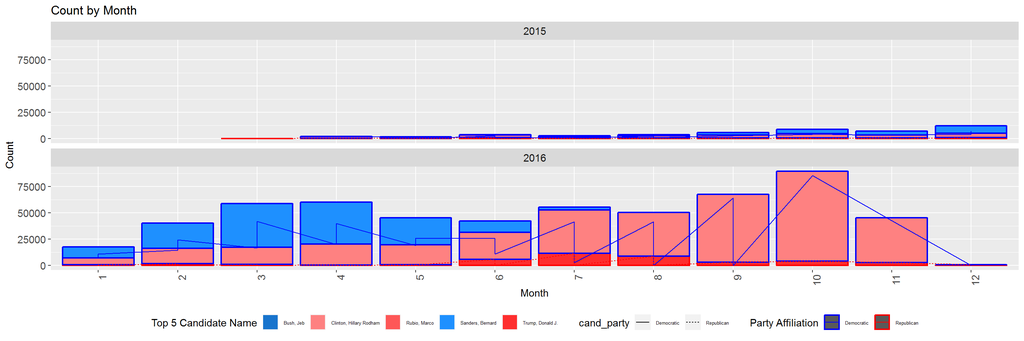

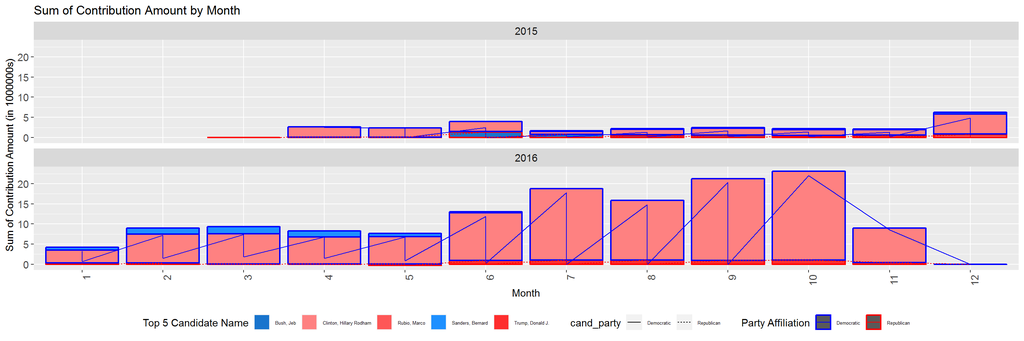

*Description Three*

> Sanders has always had higher counts of contributions until he dropped out in June 2016, where as Clinton has mostly had higher sum of contribution amount.

## Reflection:

> The 2016 Presidential Campaign Contribution dataset for New york State contains 649640 records of contributions and 18 variables. Most of the variables are of factor / categorical type, except for contribution receipt date `contb_receipt_dt` and contribution receipt amount `contb_receipt_amt`. I started by understanding the individual variables in the data set, and then I explored interesting questions and leads as I continued to make observations on plots. Eventually, I explored the count of contributions, sum of contribution amount across the selected variables and across timeline up till the end of 2016.

> Individual candidate, and candidate party affiliation are definitely strong attributes to contribution amount and the sum of it. The count of contribution is highly correlated to the sum of contribution amount, but there one isn’t necessary a good prediction of the other. The count of contributions, sum of contribution amount, by candidate and/or candidate party affiliation, definitely showed event driven trends when observed on the monthly plots over 2015 and 2016.

There are also quite some limitations on this dataset:

- not a whole lot of statistical analysis can be done given most of the variables are factor type
- data validity was not ensured
- missing data and possibly fake data on `contbr_employer`. The ‘N/A’, ‘NONE’, `is.na`, ’INFORMATION REQUESTED’It could be possible that contributors are hesitant to provide `contbr_employer` information.
- also possibly missing data and fake data on `contbr_occupation`. Notably, the top two `contbr_occupation` are ‘RETIRED’ and ‘NOT EMPLOYED’. *Why is it that these two groups, who are unlikely to have an income source, are contributing more often than others?*
- duplicate yet inconsistent data between `contbr_employer` and `contbr_occupation`. Even though values such as ‘RETIRED’, ‘SELF-EMPLOYED’, ‘NOT EMPLOYED’ and ‘SELF-EMPLOYED’ are found in both `contbr_employer` and `contbr_occupation`, the count of those values are somehow different. While the top 20 `contbr_employer` were made up by those ambiguous values, the top 20 `contbr_occupation` are clearly identified. *Contributors are more willing to disclose occupation information but not employer information.*
- untidy data and large set of distinct values in `contbr_city` and `contbr_zip` variable.

## References:

- http://stackoverflow.com/questions/8854046/duplicate-row-names-are-not-allowed-error-in-r-programming/34884041#34884041
- http://www.fec.gov/finance/disclosure/ftpdet.shtml
- http://www.fec.gov/finance/disclosure/metadata/DataDictionaryContributionstoCandidates.shtml
- http://www.fec.gov/finance/disclosure/metadata/DataDictionaryContributionsbyIndividuals.shtml
- http://www.fec.gov/finance/disclosure/metadata/DataDictionaryWEBL.shtml
- http://www.fec.gov/finance/disclosure/metadata/DataDictionaryWEBALL.shtml
- http://www.fec.gov/finance/disclosure/metadata/DataDictionaryOperatingExpenditures.shtml
- http://zevross.com/blog/2014/08/04/beautiful-plotting-in-r-a-ggplot2-cheatsheet-3/
- http://www.cookbook-r.com/Graphs/Colors_(ggplot2)/
- http://www.cookbook-r.com/Graphs/Plotting_distributions_(ggplot2)/
- http://docs.ggplot2.org/current/index.html